# Chapter 4: Covariate Model Building

MI-210 Essentials of Population PKPD M&S — Pumas Edition

Author

Adapted from Marc R. Gastonguay, Ph.D. (Metrum Institute)

Published

April 18, 2026

# 1 Overview

Covariate model building identifies measurable patient factors that explain inter-individual variability in PK/PD parameters:

- Objectives of covariate model development
- Common covariate model parameterizations
- Data reduction before covariate building
- Covariate screening methods (traditional and automated)
- Inferences about covariate effects

# 2 Objectives of Covariate Model Development

- Identify factors that explain variability in PK/PD parameters
- Reduce unexplained inter-individual variability
- Improve model predictions for individual patients
- Support dose adjustment recommendations for special populations

**Why Covariates Reduce Inter-Individual Variability**

When a covariate genuinely explains inter-individual variability, incorporating it into the model splits the single population parameter into covariate-defined subgroups, each with its own typical value. The random effect $\eta_i$ must then only account for the residual difference between the individual’s true parameter and the subgroup-specific population prediction, rather than the overall population mean. This forces $\eta$ to do less work, producing a tighter distribution and a smaller $\omega$.

**Intuitive example:** Suppose males have true CL $\approx$ 10 L/h and females have true CL $\approx$ 8 L/h. A model without a sex covariate estimates $\text{tvCL} \approx 9$ L/h with a large $\omega_{CL}$ that absorbs the male–female difference. A model that includes sex estimates $\text{tvCL}_\text{male} = 10$ and $\text{tvCL}_\text{female} = 8$, and $\omega_{CL}$ shrinks because within each group the $\eta$ values cluster more tightly around zero. The individual clearances have not changed — $\eta$ simply shifts to accommodate the new, more precise population prediction.

# 3 Common Covariate Parameterizations

## 3.1 Continuous Covariates

**Power model (centered on reference value):**

$$TVCL = \theta_1 \cdot \left(\frac{CLCR}{80}\right)^{\theta_3}$$

**Linear model:**

$$TVCL = \theta_1 + \theta_3 \cdot (CLCR - 80)$$

**Physiological Basis of Common Covariate-Parameter Relationships**

**Body weight on $V$:** The apparent volume of distribution is $V = V_P + \sum_i K_{P,i} \cdot V_{T,i}$, where $V_{T,i}$ are tissue volumes and $K_{P,i}$ are tissue-to-plasma partition coefficients. A larger body has greater tissue mass and total body water, so $V$ scales with body size. Allometric scaling formalizes this: $V \propto \text{BW}^{1.0}$ and $CL \propto \text{BW}^{0.75}$, reflecting biological scaling laws derived from fractal geometry and cross-species metabolic rate observations.

**Creatinine clearance on $CL$:** For renally eliminated drugs, clearance is proportional to glomerular filtration rate (GFR). Filtration clearance is $CL_F = f_u \cdot \text{GFR}$, where only unbound drug is filtered. The Cockcroft-Gault equation estimates $\text{CLcr}$ as a surrogate for GFR, making it a natural covariate for renal clearance.

**Hepatic function on $CL$:** For hepatically cleared drugs, the well-stirred model predicts $CL_H = \frac{Q_H \cdot f_u \cdot CL_{\text{int}}}{Q_H + f_u \cdot CL_{\text{int}}}$, where $Q_H$ is hepatic blood flow, $f_u$ is fraction unbound, and $CL_{\text{int}}$ is intrinsic clearance. Intrinsic clearance depends on hepatic enzyme activity (CYP genotype, enzyme induction/inhibition from DDIs), so covariates reflecting hepatic function or metabolizer status directly modulate $CL$.

## 3.2 Categorical Covariates

**Proportional shift:**

$$TVCL = \theta_1 \cdot (1 + \theta_3 \cdot SEX)$$

**Separate typical values:**

$$TVCL = \theta_1 \cdot (1 - SEX) + \theta_2 \cdot SEX$$

## 3.3 Desirable Properties

- Centering continuous covariates on a reference value (e.g., median)
- Power model ensures positivity of parameters
- Interpretable covariate effects (e.g., fold-change per unit)

# 4 Data and Base Model

```julia
cov_df = CSV.read(joinpath(data_dir, "poppk_wcovs.csv"), DataFrame)
rename!(cov_df,
    :ID => :id, :DV => :dv, :AMT => :amt, :TIME => :time,
    :II => :ii, :ADDL => :addl, :RATE => :rate,
)

cov_df.evid = ifelse.(cov_df.amt .> 0, 1, 0)
cov_df.cmt = fill(1, nrow(cov_df))
cov_df.dv = ifelse.(cov_df.evid .== 1, missing, cov_df.dv)

pop = read_pumas(cov_df; covariates = [:HT, :WT, :CLCR, :SEX, :AGE])
println("Subjects: ", length(pop))
```

```
Subjects: 40
```

## 4.1 EBE-Covariate Screening Plots

**η-Shrinkage Limits EBE-Based Covariate Screening**

When $\eta$-shrinkage exceeds approximately 30%, individual empirical Bayes estimates (EBEs) regress toward zero and lose their ability to reflect true inter-individual differences. This has two consequences for covariate screening: (1) genuine covariate–parameter relationships may be obscured because the $\hat{\eta}$ values have collapsed toward the population mean, and (2) spurious patterns may emerge from the shrinkage structure itself rather than from biology. A flat EBE-vs-covariate plot under high shrinkage may reflect information poverty rather than the absence of a real relationship. Always compute and report $\eta$-shrinkage before interpreting EBE-covariate diagnostic plots; when shrinkage is substantial, consider alternative screening approaches such as simulation-based diagnostics.

Before formal covariate modeling, screen ETA estimates vs. covariates:

```julia
# Base model: 1-cpt IV, BLOCK(2) OMEGA, proportional error
# From 501.ctl
base_model = @model begin
    @metadata begin
        desc = "Base PopPK Model (no covariates)"
    end
    @param begin
        tvCL   ∈ RealDomain(lower = 0.0, init = 13.0)
        tvV    ∈ RealDomain(lower = 0.0, init = 75.0)
        Ω      ∈ PSDDomain(2)
        σ_prop ∈ RealDomain(lower = 0.0, init = 0.2)
    end
    @random begin
        η ~ MvNormal(Ω)
    end
    @covariates WT CLCR SEX AGE HT
    @pre begin
        CL = tvCL * exp(η[1])
        Vc = tvV * exp(η[2])
    end
    @dynamics Central1
    @derived begin
        cp := @. Central / Vc
        dv ~ @. Normal(cp, abs(cp) * σ_prop)
    end
end
```

```
┌ Warning: Covariates WT, CLCR, SEX, AGE and HT are not used in the model.
└ @ Pumas ~/.julia/packages/Pumas/GZeMg/src/dsl/model_macro.jl:3399
```

```
PumasModel
  Parameters: tvCL, tvV, Ω, σ_prop
  Random effects: η
  Covariates: WT, CLCR, SEX, AGE, HT
  Dynamical system variables: Central
  Dynamical system type: Closed form
  Derived: dv
  Observed: dv
```

```julia
base_params = (
    tvCL = 13.0, tvV = 75.0,
    Ω = [0.04 0.02; 0.02 0.04],
    σ_prop = 0.2,
)
base_fit = fit(base_model, pop, base_params, Pumas.FOCEI())
base_fit
```

[output not shown]

```
FittedPumasModel

Dynamical system type:                 Closed form

Number of subjects:                             40

Observation records:         Active        Missing
    dv:                         560              0
    Total:                      560              0

Number of parameters:      Constant      Optimized
                                  0              6

Likelihood approximation:                     FOCE
Likelihood optimizer:                         BFGS

Termination Reason:                   GradientNorm
Log-likelihood value:                   -699.38964

-------------------
         Estimate
-------------------
tvCL     11.846
tvV      85.0
Ω₁,₁      0.057303
Ω₂,₁      0.010948
Ω₂,₂      0.061453
σ_prop    0.21302
-------------------
```

```
[ Info: Calculating predictions.
[ Info: Calculating weighted residuals.
[ Info: Calculating empirical bayes.
[ Info: Evaluating dose control parameters.
[ Info: Evaluating individual parameters.
[ Info: Done.
```

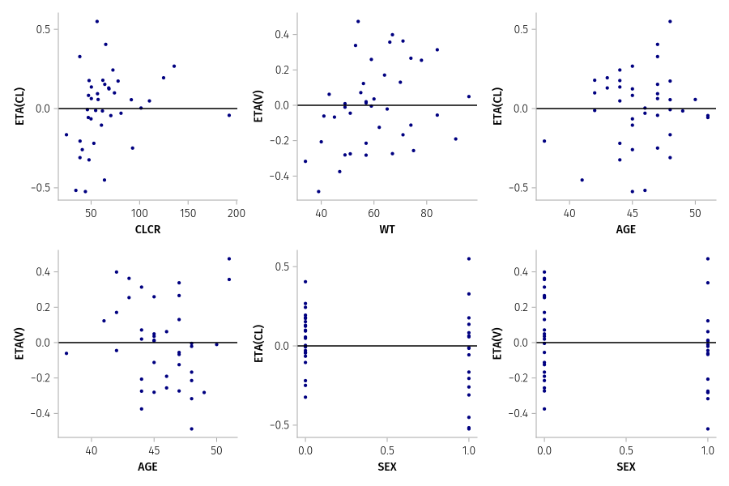

Figure 1: EBE vs Covariate Screening Plots

```julia
base_insp = inspect(base_fit)
base_df = DataFrame(base_insp)
# Get one row per subject (first obs row)
subj_df = combine(groupby(@rsubset(base_df, !ismissing(:dv)), :id), first)

fig = Figure(size = (900, 600))

ax1 = Axis(fig[1, 1], xlabel = "CLCR", ylabel = "ETA(CL)")
scatter!(ax1, subj_df.CLCR, subj_df.η₁, color = :navy, markersize = 6)
hlines!(ax1, 0, color = :black)

ax2 = Axis(fig[1, 2], xlabel = "WT", ylabel = "ETA(V)")
scatter!(ax2, subj_df.WT, subj_df.η₂, color = :navy, markersize = 6)
hlines!(ax2, 0, color = :black)

ax3 = Axis(fig[1, 3], xlabel = "AGE", ylabel = "ETA(CL)")
scatter!(ax3, subj_df.AGE, subj_df.η₁, color = :navy, markersize = 6)
hlines!(ax3, 0, color = :black)

ax4 = Axis(fig[2, 1], xlabel = "AGE", ylabel = "ETA(V)")
scatter!(ax4, subj_df.AGE, subj_df.η₂, color = :navy, markersize = 6)
hlines!(ax4, 0, color = :black)

ax5 = Axis(fig[2, 2], xlabel = "SEX", ylabel = "ETA(CL)")
scatter!(ax5, subj_df.SEX, subj_df.η₁, color = :navy, markersize = 6)
hlines!(ax5, 0, color = :black)

ax6 = Axis(fig[2, 3], xlabel = "SEX", ylabel = "ETA(V)")
scatter!(ax6, subj_df.SEX, subj_df.η₂, color = :navy, markersize = 6)
hlines!(ax6, 0, color = :black)

fig
```

# 5 Full Covariate Model

From 510.ctl — power model parameterization with CLCR and AGE on CL, WT and AGE on V:

$$TVCL = \theta_1 \cdot \left(\frac{CLCR}{80}\right)^{\theta_3} \cdot \left(\frac{AGE}{45}\right)^{\theta_4}$$

$$TVV = \theta_2 \cdot \left(\frac{WT}{70}\right)^{\theta_5} \cdot \left(\frac{AGE}{45}\right)^{\theta_6}$$

```julia
full_cov_model = @model begin
    @metadata begin
        desc = "Full Covariate Model (power parameterization)"
    end
    @param begin
        tvCL      ∈ RealDomain(lower = 0.0, init = 13.0)
        tvV       ∈ RealDomain(lower = 0.0, init = 75.0)
        dCL_CLCR  ∈ RealDomain(init = 0.5)      # THETA(3): CL~CLCR power
        dCL_AGE   ∈ RealDomain(init = -0.3)      # THETA(4): CL~AGE power
        dV_WT     ∈ RealDomain(init = 0.5)        # THETA(5): V~WT power
        dV_AGE    ∈ RealDomain(init = 0.1)         # THETA(6): V~AGE power
        Ω         ∈ PSDDomain(2)
        σ_prop    ∈ RealDomain(lower = 0.0, init = 0.2)
    end
    @random begin
        η ~ MvNormal(Ω)
    end
    @covariates WT CLCR AGE SEX HT
    @pre begin
        TVCL = tvCL * (CLCR / 80)^dCL_CLCR * (AGE / 45)^dCL_AGE
        CL   = TVCL * exp(η[1])
        TVV  = tvV * (WT / 70)^dV_WT * (AGE / 45)^dV_AGE
        Vc   = TVV * exp(η[2])
    end
    @dynamics Central1
    @derived begin
        cp := @. Central / Vc
        dv ~ @. Normal(cp, abs(cp) * σ_prop)
    end
end
```

```
┌ Warning: Covariates SEX and HT are not used in the model.
└ @ Pumas ~/.julia/packages/Pumas/GZeMg/src/dsl/model_macro.jl:3399
```

```
PumasModel
  Parameters: tvCL, tvV, dCL_CLCR, dCL_AGE, dV_WT, dV_AGE, Ω, σ_prop
  Random effects: η
  Covariates: WT, CLCR, AGE, SEX, HT
  Dynamical system variables: Central
  Dynamical system type: Closed form
  Derived: dv
  Observed: dv
```

```julia
full_params = (
    tvCL = 13.0, tvV = 75.0,
    dCL_CLCR = 0.5, dCL_AGE = -0.3,
    dV_WT = 0.5, dV_AGE = 0.1,
    Ω = [0.04 0.02; 0.02 0.04],
    σ_prop = 0.2,
)
full_fit = fit(full_cov_model, pop, full_params, Pumas.FOCEI())
full_fit
```

[output not shown]

[output cut: 16 more lines]

[output not shown]

```
FittedPumasModel

Dynamical system type:                 Closed form

Number of subjects:                             40

Observation records:         Active        Missing
    dv:                         560              0
    Total:                      560              0

Number of parameters:      Constant      Optimized
                                  0             10

Likelihood approximation:                     FOCE
Likelihood optimizer:                         BFGS

Termination Reason:                   GradientNorm
Log-likelihood value:                   -694.11224

---------------------
           Estimate
---------------------
tvCL       12.462
tvV        91.672
dCL_CLCR    0.21568
dCL_AGE     0.55065
dV_WT       0.40743
dV_AGE     -0.45537
Ω₁,₁        0.049235
Ω₂,₁        0.003531
Ω₂,₂        0.050735
σ_prop      0.21309
---------------------
```

```julia
full_infer = infer(full_fit)
full_infer
```

```
[ Info: Calculating: variance-covariance matrix.
[ Info: Done.
```

```
Asymptotic inference results using sandwich estimator

Dynamical system type:                 Closed form

Number of subjects:                             40

Observation records:         Active        Missing
    dv:                         560              0
    Total:                      560              0

Number of parameters:      Constant      Optimized
                                  0             10

Likelihood approximation:                     FOCE
Likelihood optimizer:                         BFGS

Termination Reason:                   GradientNorm
Log-likelihood value:                   -694.11224

------------------------------------------------------------
           Estimate    SE          95.0% C.I.
------------------------------------------------------------
tvCL       12.462      0.51434     [ 11.454   ;  13.47    ]
tvV        91.672      4.4503      [ 82.949   ; 100.39    ]
dCL_CLCR    0.21568    0.092126    [  0.035111;   0.39624 ]
dCL_AGE     0.55065    0.49402     [ -0.41761 ;   1.5189  ]
dV_WT       0.40743    0.15347     [  0.10663 ;   0.70824 ]
dV_AGE     -0.45537    0.73577     [ -1.8975  ;   0.9867  ]
Ω₁,₁        0.049235   0.011635    [  0.026431;   0.072038]
Ω₂,₁        0.003531   0.0070028   [ -0.010194;   0.017256]
Ω₂,₂        0.050735   0.012472    [  0.026289;   0.07518 ]
σ_prop      0.21309    0.0093414   [  0.19478 ;   0.2314  ]
------------------------------------------------------------
```

# 6 Model Comparison

```julia
println("Covariate Model Comparison")
println("=" ^ 50)
println("Base Model    AIC: ", round(aic(base_fit), digits = 1))
println("Full Cov      AIC: ", round(aic(full_fit), digits = 1))

delta_ofv = -2 * loglikelihood(base_fit) - (-2 * loglikelihood(full_fit))
println("\nDelta OFV: ", round(delta_ofv, digits = 2), " (4 df)")
println("Chi-sq critical (p=0.05, 4df): 9.49")
println("Chi-sq critical (p=0.005, 4df): 14.86")
```

```
Covariate Model Comparison
==================================================
Base Model    AIC: 1410.8
Full Cov      AIC: 1408.2

Delta OFV: 10.55 (4 df)
Chi-sq critical (p=0.05, 4df): 9.49
Chi-sq critical (p=0.005, 4df): 14.86
```

# 7 Covariate Modeling Methods in Pumas

## 7.1 Automated Covariate Selection

Pumas provides `covariate_select()` for automated forward addition / backward elimination. The key design principle: **define all covariate effects in the model upfront**, then use `control_param` to specify which parameters “turn on/off” each effect. Setting a control parameter to zero removes its covariate effect.

### 7.1.1 Forward Selection

Starts with base model (all covariate effects zeroed out), iteratively adds the single most impactful covariate:

```julia
# Step 1: Define model with ALL candidate covariate effects pre-coded
full_cov_model = @model begin
    @param begin
        tvCL     ∈ RealDomain(lower = 0.0, init = 4.0)
        tvV      ∈ RealDomain(lower = 0.0, init = 70.0)
        dWTCL    ∈ RealDomain(init = 0.0)     # WT effect on CL (power)
        dWTV     ∈ RealDomain(init = 0.0)     # WT effect on V (power)
        dCLCR_CL ∈ RealDomain(init = 0.0)     # CLCR effect on CL (power)
        dAGE_CL  ∈ RealDomain(init = 0.0)     # AGE effect on CL (power)
        dSEX_CL  ∈ RealDomain(init = 0.0)     # SEX effect on CL (proportional shift)
        Ω        ∈ PSDDomain(2)
        σ_prop   ∈ RealDomain(lower = 0.0, init = 0.2)
    end
    @random begin
        η ~ MvNormal(Ω)
    end
    @covariates WT CLCR AGE SEX
    @pre begin
        CL = tvCL * (WT / 70)^dWTCL * (CLCR / 80)^dCLCR_CL *
             (AGE / 45)^dAGE_CL * (1 + dSEX_CL * (SEX == 1)) * exp(η[1])
        Vc = tvV * (WT / 70)^dWTV * exp(η[2])
    end
    @dynamics Central1
    @derived begin
        cp := @. Central / Vc
        dv ~ @. Normal(cp, abs(cp) * σ_prop)
    end
end

# Step 2: Forward selection — control_param lists the covariate effect parameters
covar_result = covariate_select(
    full_cov_model, pop, init_params, Pumas.FOCEI();
    control_param = (:dWTCL, :dWTV, :dCLCR_CL, :dAGE_CL, :dSEX_CL),
    method = CovariateSelection.Forward,
    criterion = aic,
)

# Access results
covar_result.best_model    # final selected model
covar_result.fits          # all intermediate fits
```

### 7.1.2 Backward Elimination

Starts with full model (all effects active), iteratively removes the least impactful:

```julia
covar_result_be = covariate_select(
    full_cov_model, pop, full_params, Pumas.FOCEI();
    control_param = (:dWTCL, :dWTV, :dCLCR_CL, :dAGE_CL, :dSEX_CL),
    method = CovariateSelection.Backward,
    criterion = bic,   # BIC penalizes complexity more than AIC
)
```

**Covariate Selection Methodologies: SCM, GAM, and FFM**

**Stepwise Covariate Modeling (SCM):** The most widely used approach, consisting of forward addition followed by backward elimination within the full nonlinear mixed-effects model. Forward steps add covariates using a liberal threshold (e.g., $p < 0.05$); backward steps remove covariates using a stricter threshold (e.g., $p < 0.001$). Each step constitutes a hypothesis test, raising concerns about alpha spending from multiple comparisons — in practice, corrections such as Bonferroni are rarely applied, which is a known limitation.

**Generalized Additive Modeling (GAM):** A non-parametric, EBE-based screening method that operates outside the PK model. Individual $\hat{\eta}$ values are regressed against candidate covariates using simple linear models, and the best-fitting covariate is selected iteratively. GAM is computationally efficient but inherits the shrinkage bias of EBEs: when $\eta$-shrinkage is substantial, GAM results may be unreliable.

**Full Fixed-Effects Model (FFM):** All biologically plausible covariates are included simultaneously from the outset, and no stepwise hypothesis testing is performed. Covariate importance is judged by the clinical significance of effect magnitudes (e.g., whether a covariate shifts exposure by $\geq$ 20%) rather than by $p$-values. FFM avoids the multiple-testing problem inherent in SCM but requires careful prior identification and de-correlation of candidate covariates using domain knowledge.

### 7.1.3 AIC vs BIC vs LRT

| Criterion | Formula | Favors |
| --- | --- | --- |
| AIC | $-2LL + 2k$ | Predictive accuracy; may overfit with large n |
| BIC | $-2LL + k \cdot \log(n)$ | Parsimony; stronger penalty for large datasets |
| LRT | $\Delta OFV \sim \chi^2(\Delta df)$ | Nested model comparison only; requires p-value cutoff |

- **Forward selection:** typically use AIC (p ≈ 0.05 equivalent) or LRT with α = 0.05
- **Backward elimination:** typically use BIC or LRT with stricter α = 0.01 (or 0.001)
- AIC and BIC work for both nested and non-nested models

**Tip**

**NONMEM vs Pumas Covariate Workflow:**

- NONMEM: Manual control stream editing + SCM in PsN
- Pumas: `covariate_select()` automates forward/backward selection, or use manual AIC/LRT comparison as shown above

## 7.2 Time-Varying Covariates

Covariates that change during the study (e.g., weight, creatinine clearance, concomitant medications) require special handling:

```julia
# In the dataset: include covariate values at each observation/event time
# Pumas interpolates between recorded values using piece-wise constant interpolation:
#   :left  → LOCF (Last Observation Carried Forward) — Pumas default
#   :right → NOCB (Next Observation Carried Backward) — NONMEM default

pop = read_pumas(df; covariates = [:WT, :CLCR], covariates_direction = :left)

# The covariate is automatically available as a time-varying quantity in @pre
```

**Warning**

**NONMEM defaults to NOCB** (right-continuous interpolation), while **Pumas defaults to LOCF** (left-continuous). When comparing results between the two, explicitly set `covariates_direction = :right` in Pumas for NONMEM equivalence.

## 7.3 Missing Covariates in Population Models

| Strategy | When to Use | Pumas Implementation |
| --- | --- | --- |
| Median imputation | Standard approach for sporadic missingness | `@rtransform :WT = coalesce(:WT, 70.0)` before `read_pumas` |
| Group-wise imputation | When covariate differs by subgroup | `groupby(:SEX)` → `@transform :WT = coalesce.(:WT, median(skipmissing(:WT)))` |
| Complete case | When missingness is minimal | `dropmissing(df, [:WT, :CLCR])` |
| Flag + sensitivity | When imputation impact is uncertain | Add `:WT_IMPUTED` column, run with/without imputed subjects |

# 8 GOF Diagnostics: Full Model

```
[ Info: Calculating predictions.
[ Info: Calculating weighted residuals.
[ Info: Calculating empirical bayes.
[ Info: Evaluating dose control parameters.
[ Info: Evaluating individual parameters.
[ Info: Done.
```

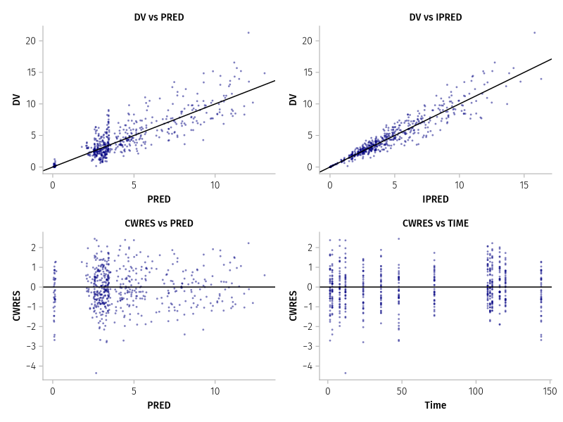

Figure 2: Full Covariate Model GOF Diagnostics

```julia
full_insp = inspect(full_fit)
full_df = DataFrame(full_insp)
obs = @rsubset(full_df, !ismissing(:dv))

fig = Figure(size = (800, 600))

ax1 = Axis(fig[1, 1], xlabel = "PRED", ylabel = "DV", title = "DV vs PRED")
scatter!(ax1, obs.dv_pred, obs.dv, color = :navy, markersize = 4, alpha = 0.5)
ablines!(ax1, 0, 1, color = :black)

ax2 = Axis(fig[1, 2], xlabel = "IPRED", ylabel = "DV", title = "DV vs IPRED")
scatter!(ax2, obs.dv_ipred, obs.dv, color = :navy, markersize = 4, alpha = 0.5)
ablines!(ax2, 0, 1, color = :black)

ax3 = Axis(fig[2, 1], xlabel = "PRED", ylabel = "CWRES", title = "CWRES vs PRED")
scatter!(ax3, obs.dv_pred, obs.dv_wres, color = :navy, markersize = 4, alpha = 0.5)
hlines!(ax3, 0, color = :black)

ax4 = Axis(fig[2, 2], xlabel = "Time", ylabel = "CWRES", title = "CWRES vs TIME")
scatter!(ax4, obs.time, obs.dv_wres, color = :navy, markersize = 4, alpha = 0.5)
hlines!(ax4, 0, color = :black)

fig
```

# 9 Study Guide Questions

1. What are desirable properties of covariate-parameter models?
2. How does centering a continuous covariate on its median help interpretation?
3. What is the difference between forward addition and backward elimination?
4. When might a statistically significant covariate NOT be clinically relevant?
5. What are the limitations of using EBE-based covariate screening?
6. How would you calculate the initial estimate for OMEGA assuming 30% CV with exponential IIV?

# 10 Supplementary Material

| Topic | Tutorial | Key Additions |
| --- | --- | --- |
| **Lecture: Covariate Fundamentals** | PKPD W7.5 | Covariate types, functional forms, parameterization strategies |
| **Lecture: Covariate Diagnostics & Methodology** | PKPD W8 | EBE screening, η-shrinkage, SCM/GAM/FFM comparison |
| **Lecture: Volume of Distribution** | PK W4 | Why body weight affects V — tissue mass, body water, protein binding |
| **Lecture: Renal Elimination** | PK W7b | Why CLcr predicts CL — GFR, filtration, secretion, reabsorption |
| Covariate model introduction | [Covariates](https://tutorials.pumas.ai/html/introduction/covariate.html) | Allometric scaling, hepatic/renal CL breakdown, time-varying covariates, categorical effects |
| AIC/BIC/LRT theory | [Covariate Selection Intro](https://tutorials.pumas.ai/html/covariate_select/01-intro.html) | Mathematical derivations, penalty comparison, custom OFV functions |
| Forward selection workflow | [Forward Selection](https://tutorials.pumas.ai/html/covariate_select/02-forward_selection.html) | `covariate_select()` API, control_param patterns, custom criteria |
| Backward elimination workflow | [Backward Elimination](https://tutorials.pumas.ai/html/covariate_select/03-backward_elimination.html) | Full backward workflow, BIC criterion, result interpretation |
| Mixed stepwise (SCM) | [Mixed Selection](https://tutorials.pumas.ai/html/covariate_select/04-mixed.html) | Combined forward + backward in one pipeline |
| Cloud batch covariate search | [Batch Job](https://tutorials.pumas.ai/html/covariate_select/05-batch_job.html) | Running covariate_select on JuliaHub for large populations |